# Bay of Biscay and the Iberian Coast

#### Figure 3

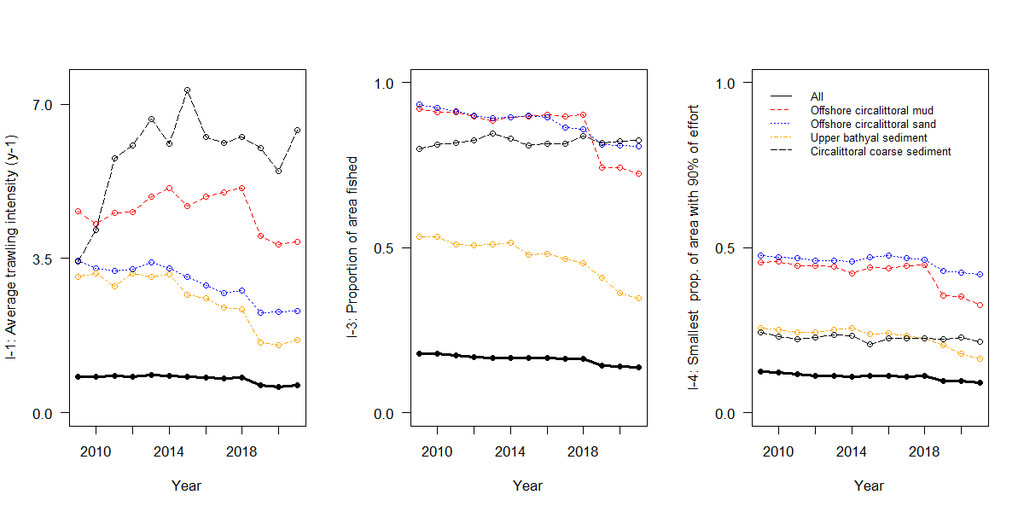

**Figure 3. Time series of (a) mean fishing intensity (surface abrasion), (b) proportion of the surface area of the seafloor fished, (c) aggregation of fishing (proportion of the surface area with 90% of the fishing effort) by habitat. Results represent vessels over 15m (2009-2011) and vessels over 12m (2012-2021).**

#### Figure 4

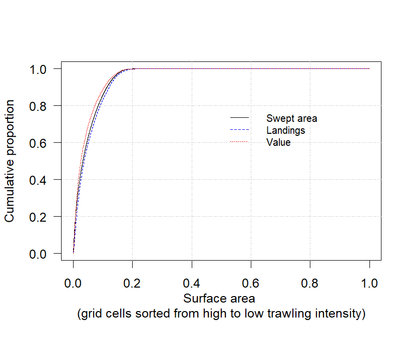

**Figure 4. Cumulative proportion of the swept area, landings and value. Grid cells were sorted from highest to lowest fishing intensity and include non-fished cells. The results are for all mobile bottom-contacting gears based on averaged fishing data per c-square from 2016-2021.**

### Core fishing grounds

No information available

### Fishing by métier

Area swept is estimated for the grid cells that were fished by one MBCG métier, ignoring cells fished by other métiers (Table 3).

#### Table 3

Table 3. Overview of area fished (sum of swept area), landings and value for the different metiers. Area fished in 1000 km2, weight of landings in 1000 tonnes, value of landings in 10^6 euro.

|  | DRB_MOL | OT_CRU | OT_DMF | OT_MI | OT_SPF | SDN_DMF | SSC_DMF | TBB_CRU | TBB_DMF | TBB_MOL |
| --- | --- | --- | --- | --- | --- | --- | --- | --- | --- | --- |
| Area swept (1000 km2) | 0.05 | 201.41 | 238.68 | 49.36 | 1.65 | 51.89 | 0.02 | 0 | 2.45 | 0 |
| Landings (1000 tonnes) | NA | NA | NA | NA | NA | NA | NA | NA | NA | NA |
| Value (10^6 euro) | 0.10 | 38.59 | 37.60 | 17.99 | 0.89 | 8.87 | <0.005 | 0 | 4.10 | 0 |
| Landings (1000 tonnes)/Area swept (1000 km2) | 4.81 | 0.11 | 0.14 | 0.26 | 0.46 | 0.04 | 0.05 | NA | 0.21 | NA |
| Value (10^6 euro)/Area swept (1000 km2) | NA | NA | NA | NA | NA | NA | NA | NA | NA | NA |

### Impact

No information available

### Management scenarios

No information available on value/weight of landings.

#### Overview all MSFD habitats

Fishing effort consequences, as a % relative to total swept area, of protecting a certain fraction of each broad habitat type sorted from low to high fished c-squares

| MSFD broad habitat type | Extent of habitat 1000 km<sup>2</sup> | 0.05 | 0.1 | 0.2 | 0.3 | 0.4 | 0.5 | 0.6 | 0.7 | 0.8 | 0.9 |
| --- | --- | --- | --- | --- | --- | --- | --- | --- | --- | --- | --- |
| Offshore circalittoral mud | 31.66 | <0.1 | 0.8 | 4.0 | 8.7 | 14.3 | 20.8 | 28.2 | 36.9 | 47.9 | 64.1 |
| Offshore circalittoral sand | 36.15 | 0.2 | 1.3 | 5.3 | 11.4 | 18.1 | 26.8 | 36.5 | 47.3 | 60.2 | 76.3 |
| Upper bathyal sediment | 36.91 | 0.0 | 0.0 | 0.0 | <0.1 | 0.2 | 1.4 | 4.6 | 11.2 | 24.1 | 47.3 |
| Circalittoral coarse sediment | 8.68 | <0.1 | <0.1 | 1.0 | 4.7 | 10.7 | 19.2 | 29.2 | 39.9 | 53.2 | 70.6 |
| Circalittoral sand | 16.74 | 0.0 | 0.0 | <0.1 | 0.3 | 2.4 | 7.7 | 15.8 | 26.1 | 39.9 | 59.9 |
| Offshore circalittoral coarse sediment | 12.02 | 1.1 | 3.4 | 8.4 | 13.8 | 20.9 | 28.3 | 37.5 | 47.0 | 58.8 | 73.5 |
| Circalittoral mud | 6.46 | 0.0 | 0.0 | 0.0 | <0.1 | 0.4 | 1.7 | 5.1 | 11.8 | 26.2 | 50.5 |
| Offshore circalittoral mixed sediment | 3.36 | 0.1 | 1.0 | 4.5 | 9.4 | 15.9 | 23.8 | 32.5 | 42.8 | 60.2 | 78.1 |
| Offshore circalittoral rock and biogenic reef | 7.04 | 0.0 | <0.1 | 1.4 | 6.0 | 12.7 | 21.2 | 30.8 | 42.8 | 57.6 | 74.4 |
| Circalittoral mixed sediment | 2.99 | 0.0 | 0.0 | 0.0 | <0.1 | 0.3 | 1.2 | 8.7 | 19.7 | 36.4 | 59.1 |
| Upper bathyal sediment or Upper bathyal rock and biogenic reef | 21.49 | 0.0 | 0.0 | 0.0 | 0.0 | 0.0 | 0.0 | <0.1 | 0.5 | 3.7 | 22.2 |
| Circalittoral rock and biogenic reef | 7.11 | 0.0 | 0.0 | 0.0 | 0.0 | 0.2 | 1.3 | 4.0 | 9.6 | 21.4 | 43.6 |
| Upper bathyal rock and biogenic reef | 1.86 | 0.0 | 0.0 | 0.0 | 0.0 | 0.0 | <0.1 | 1.6 | 8.1 | 25.4 | 54.7 |
| Infralittoral sand | 2.58 | 0.0 | 0.0 | 0.0 | 0.0 | 0.0 | 0.0 | <0.1 | 0.5 | 2.0 | 10.1 |
| Lower bathyal sediment or Lower bathyal rock and biogenic reef | 36.23 | 0.0 | 0.0 | 0.0 | 0.0 | 0.0 | 0.0 | 0.0 | 0.0 | 0.0 | 0.0 |
| Infralittoral mixed sediment | 0.4 | 0.0 | 0.0 | 0.0 | 0.0 | 0.0 | 0.0 | <0.1 | 0.4 | 2.1 | 23.6 |
| Unknown | 0.74 | 0.0 | 0.0 | 0.0 | 0.0 | 0.0 | 0.0 | 0.0 | 0.0 | 0.2 | 20.8 |
| Infralittoral mud | 0.79 | 0.0 | 0.0 | 0.0 | 0.0 | 0.0 | 0.0 | 0.0 | 0.4 | 2.0 | 11.8 |
| Infralittoral rock and biogenic reef | 2.05 | 0.0 | 0.0 | 0.0 | 0.0 | 0.0 | 0.0 | 0.0 | 0.5 | 3.6 | 18.1 |
| Infralittoral coarse sediment | 0.53 | 0.0 | 0.0 | 0.0 | 0.0 | <0.1 | 0.4 | 2.0 | 4.0 | 7.1 | 21.3 |
| Lower bathyal sediment | 12.33 | 0.0 | 0.0 | 0.0 | 0.0 | 0.0 | 0.0 | 0.0 | 0.0 | 0.8 | 7.1 |
| Abyssal | 515.24 | 0.0 | 0.0 | 0.0 | 0.0 | 0.0 | 0.0 | 0.0 | 0.0 | 0.0 | 0.0 |
| Lower bathyal rock and biogenic reef | 0.49 | 0.0 | 0.0 | 0.0 | 0.0 | 0.0 | 0.0 | 0.0 | 0.0 | 0.0 | 0.0 |

## Bay of Biscay - shallow

### Summary

The physical disturbance pressures from mobile bottom-contacting fishing gears varies spatially in the “Bay of Biscay shallow” subdivision with 92% of the grid cells (I-2), and 80% of the surface area (I-3), in the depth zone 0-200m, being fished on average per year for the period 2013-2018 (Table 1). Fishing is relatively aggregated with 90% of the pressure occurring in 56% of grid cells (I-4).

The ICES methods for computing impact are not available at the moment in the region and therefore this part of the analysis has not been completed.

Maps of spatial distribution of intensity, seafloor sensitivity and economic value and weight of fisheries landings are shown in Figure 1. It is evident from the weight map that there is a mistake in the values for the region, and weights are not presented in further analyses.

#### Table 1

Table 1. Pressure and impact indicators for 2016-2021

| Indicators | 0 to 200 m | 200 to 800 m | more than 800 m |
| --- | --- | --- | --- |
| Average intensity (I-1) | 3.53 | NA | NA |
| Proportion of area in fished cells (I-2) | 0.93 | NA | NA |
| Proportion of area fished per year (I-3) | 0.82 | NA | NA |
| Smallest prop. of area in fished cells with 90% of fishing effort (I-4) | 0.57 | NA | NA |
| Proportion of area in unfished cells (I-5) | 0.07 | NA | NA |
| Average PD impact (I-6) | NA | NA | NA |
| Average L1 impact (I-6) | NA | NA | NA |
| Proportion of area with PD impact < 0.2 (I-7) | NA | NA | NA |
| Proportion of area with L1 impact < 0.2 (I-7) | NA | NA | NA |

#### Figure 1

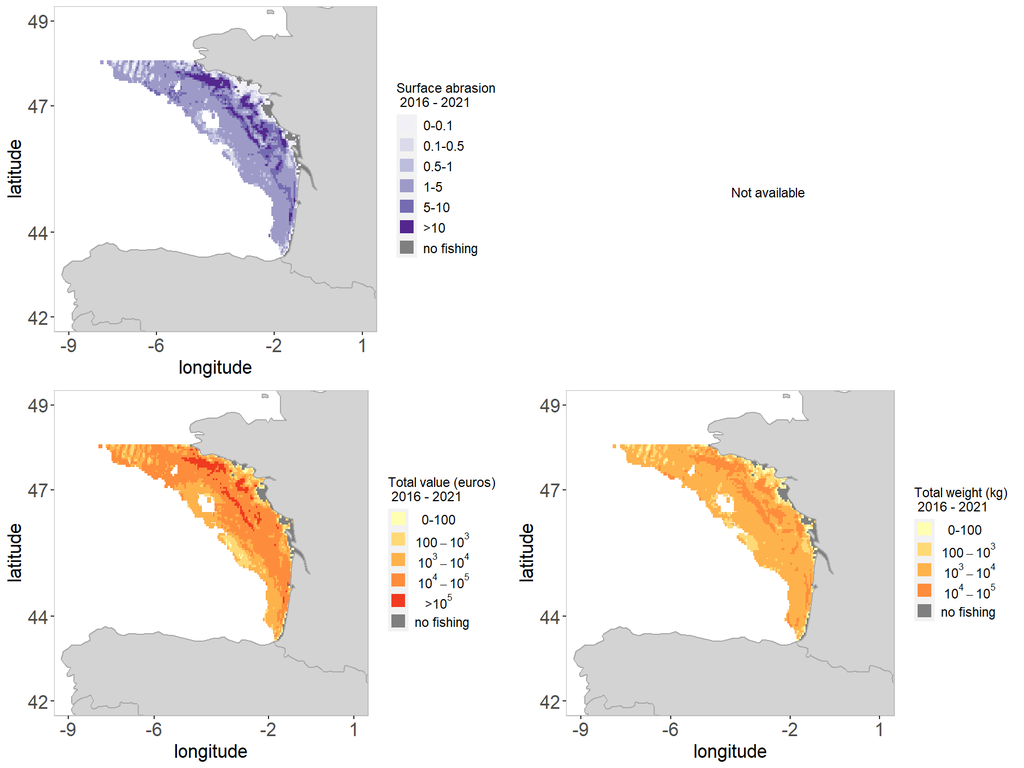

**Figure 1 Geographic distribution of surface abrasion, seabed sensitivity (not shown) and total value and weight from mobile bottom-contacting gear. The maps of surface abrasion, value and weight show the average per year for 2016-2021**